# Analysis of distributed input

Here we present the three main measures separated by input representation. Nets which received localist input are labeled *False* and are plotted on the left. The script generating these results has been checked for likely errors, so these results should be taken seriously. If there is a “mistake”, it is most likely related to how we translate the localist representations of the corpora to distributed representations.

## Word segmentation

Danish performance improves while English worsens, eliminating the main effect of language. This could imply that there is more distributional information in Danish than in English. Note that if there is no distributional information, then a net will perform worse than it will with localist input because it will essentially have to learn to create a localist representation from the distributed input.

It’s also possible that the specific encoding we are using is more favorable for Danish. It’s perhaps worth noting that a Danish phonologist constructed it. Most notably, the English nets receive diphthongs as two independent tokens.

```
##                   Df  Sum Sq Mean Sq F value   Pr(>F)
## lang               1 0.03029 0.03029  11.748 0.000863 ***
## distributed        1 0.01086 0.01086   4.211 0.042590 *
## lang:distributed   1 0.06964 0.06964  27.011 9.64e-07 ***
## Residuals        108 0.27846 0.00258
## ---
## Signif. codes:  0 '***' 0.001 '**' 0.01 '*' 0.05 '.' 0.1 ' ' 1
```

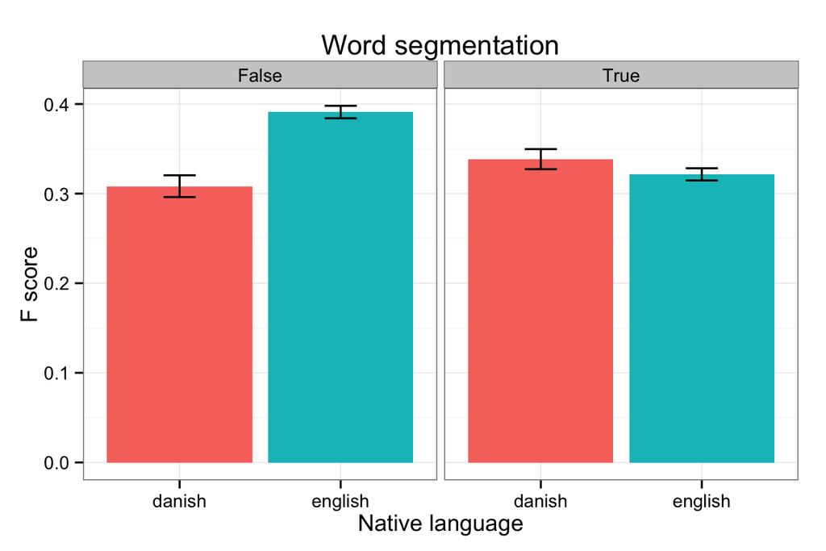

## Artificial word learning

Most notably, we see that performance is worse across the board with distributed input. In fact, it is at or below chance. Seeing as Danish performance worsens on the artificial word learning, but improves on the word segmentation, one possible explanation is that distributed representations take more examples to learn—training is much more limited on the artificial task.

```
##                             Df Sum Sq Mean Sq F value  Pr(>F)
## condition                    1 0.0014  0.0014   0.186 0.66674
## lang                         1 0.0001  0.0001   0.007 0.93135
## distributed                  1 1.9067  1.9067 257.317 < 2e-16 ***
## condition:lang               1 0.0031  0.0031   0.418 0.51844
## condition:distributed        1 0.0132  0.0132   1.787 0.18271
## lang:distributed             1 0.0547  0.0547   7.380 0.00713 **
## condition:lang:distributed   1 0.0035  0.0035   0.476 0.49097
## Residuals                  216 1.6006  0.0074
## ---
## Signif. codes:  0 '***' 0.001 '**' 0.01 '*' 0.05 '.' 0.1 ' ' 1
```

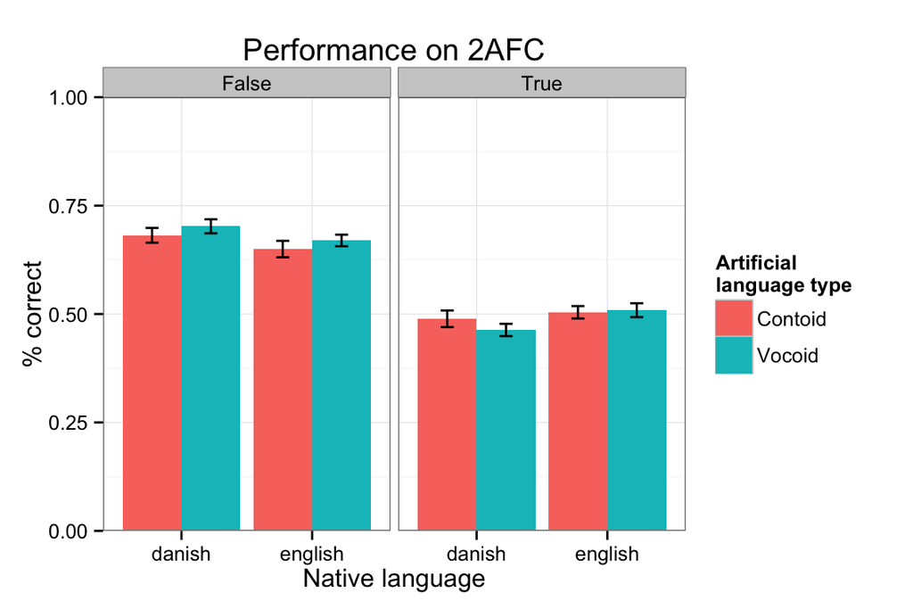

## Reaction times

Reaction times are higher across the board for distributed input, especially for danish contoids, a pattern that remains when eliminating outliers. However we do see that the general pattern is the same for localist and distributed input.

When we compare these results to our initial results, however, we see little agreement. It appears that by only taking the reaction times for correct trials (a change from our original methodology), we have completely changed the pattern of localist results. Danish reaction times have increased dramatically for contoids and decreased slightly for vocoids. English reaction times are similar for contoids and higher for vocoids, with the overall pattern switching directions.

```
##                             Df  Sum Sq Mean Sq F value   Pr(>F)
## condition                    1  190874  190874   28.36 2.53e-07 ***
## lang                         1  150249  150249   22.32 4.16e-06 ***
## distributed                  1  223541  223541   33.21 2.83e-08 ***
## condition:lang               1  143404  143404   21.30 6.72e-06 ***
## condition:distributed        1  151980  151980   22.58 3.68e-06 ***
## lang:distributed             1  126857  126857   18.84 2.18e-05 ***
## condition:lang:distributed   1  107192  107192   15.92 9.03e-05 ***
## Residuals                  216 1454029    6732
## ---
## Signif. codes:  0 '***' 0.001 '**' 0.01 '*' 0.05 '.' 0.1 ' ' 1
```

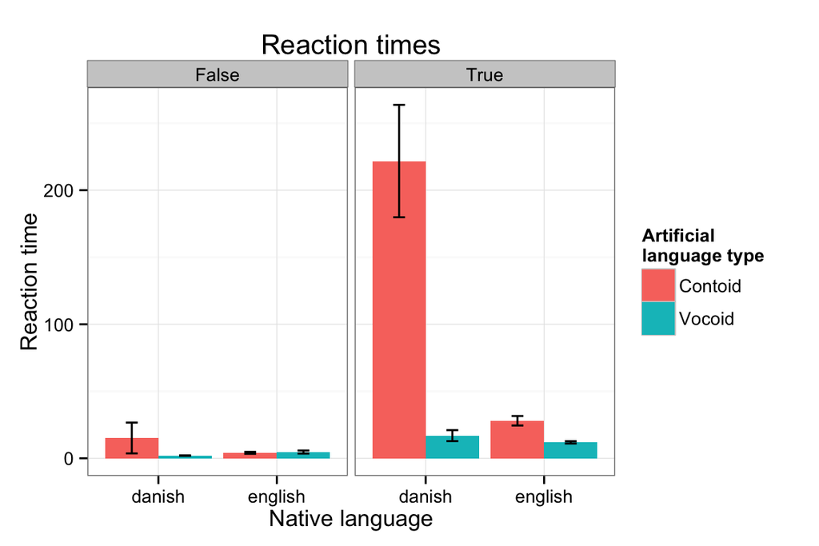

## Next steps

- See if we can get distributed 2AFC to perform above chance by using a deterministic choice function.
- See if we can create a less probabilistic choice function that reduces the variance of 2AFC accuracies, giving us the power to identify a main effect.
  - One possibility is to use a sigmoidal rather than linear choice function, making the net more likely to choose the lower error word.
- Figure out what the heck is going on with reaction times.